# HUDK4050-Assignment 2

Minruo Wang

10/3/2019

# Assignment 2 - Social Network Analysis

## Part I

Start by installing the “igraph” package. Once you have installed igraph, load the package.

```r
# install
# install.packages("igraph")
# load
library("igraph")
```

Now upload the data file “discipline-data.csv” as a data frame called “D1”. Each row is a disciplinary action from a teacher to a student so the first line shows that teacher “E” sent student “21” to the principal. It also shows the gender of both the teacher and student and the student’s main elective field of study (“major”“) and the field that the teacher instructs in (”t.expertise").

```r
# load data
D1 <- read.csv("discipline-data.csv", header = TRUE, sep = ",")
```

```r
# change data type from integer to factor
D1$stid <- as.character(D1$stid)
typeof(D1$stid)
```

```
## [1] "character"
```

igraph requires data to be in a particular structure. There are several structures that it can use but we will be using a combination of an “edge list” and a “vertex list”. As you might imagine the edge list contains a list of all the relationships between students and teachers and any characteristics of those edges that we might be interested in.  
There are two essential variables in the edge list a “from” variable and a “to” variable that descibe the relationships between vertices (a disciplinary action is given “from” and teacher “to” a student). While the vertix list contains all the characteristics of those vertices, in our case gender and major.

So let’s convert our data into an edge list!

First we will isolate the variables that are of interest: tid and stid

```r
library(dplyr)
# select relevant variables into an edge list
D2 <- select(D1, tid, stid)
```

Since our data represnts every time a teacher sends a student to the principal there are multiple rows when the same teacher sends the same student. We want to collapse these into a single row, with a variable that shows how many times a teacher-student pair appears.

```r
# count the number of 1-to-1 relationships (create a new variable)
EDGE <- count(D2, tid, stid)
# name
names(EDGE) <- c("from", "to", "count")
# show the edge list
head(EDGE)
```

```
## # A tibble: 6 x 3
##   from  to    count
##   <fct> <chr> <int>
## 1 A     18        1
## 2 A     2         1
## 3 A     22        1
## 4 A     25        2
## 5 A     3         1
## 6 A     4         2
```

EDGE is your edge list. Now we need to make the vertex list, a list of all the teachers and students and their characteristics in our network.

```r
# First we will separate the teachers from our original data frame
V.TCH <- select(D1, tid, t.gender, t.expertise)
#Remove all the repeats so that we just have a list of each teacher and their characteristics
V.TCH <- unique(V.TCH)
#Add a variable that describes that they are teachers
V.TCH$group <- "teacher"

#Now repeat this process for the students
V.STD <- select(D1, stid, s.gender, s.major)
V.STD <- unique(V.STD)
V.STD$group <- "student"

#Make sure that the student and teacher data frames have the same variables names
names(V.TCH) <- c("id", "gender", "topic", "group")
names(V.STD) <- c("id", "gender", "topic", "group")

#Bind the two data frames together (you will get a warning because the teacher data frame has 5 types of id (A,B,C,D,E) and the student has 25 (1-30), this isn't a problem)
VERTEX <- rbind(V.TCH, V.STD)
VERTEX
```

```
##     id gender   topic   group
## 1    E female     art teacher
## 2    A female biology teacher
## 5    D female     art teacher
## 7    B   male    math teacher
## 10   C   male biology teacher
## 11  21 female     art student
## 25   4   male    math student
## 3   25   male biology student
## 4   15 female english student
## 51   1   male biology student
## 6    8   male english student
## 101 10   male     art student
## 12  26 female     art student
## 13  23 female     art student
```

[output cut: 16 more lines]

Now we have both a Vertex and Edge list it is time to plot our graph!

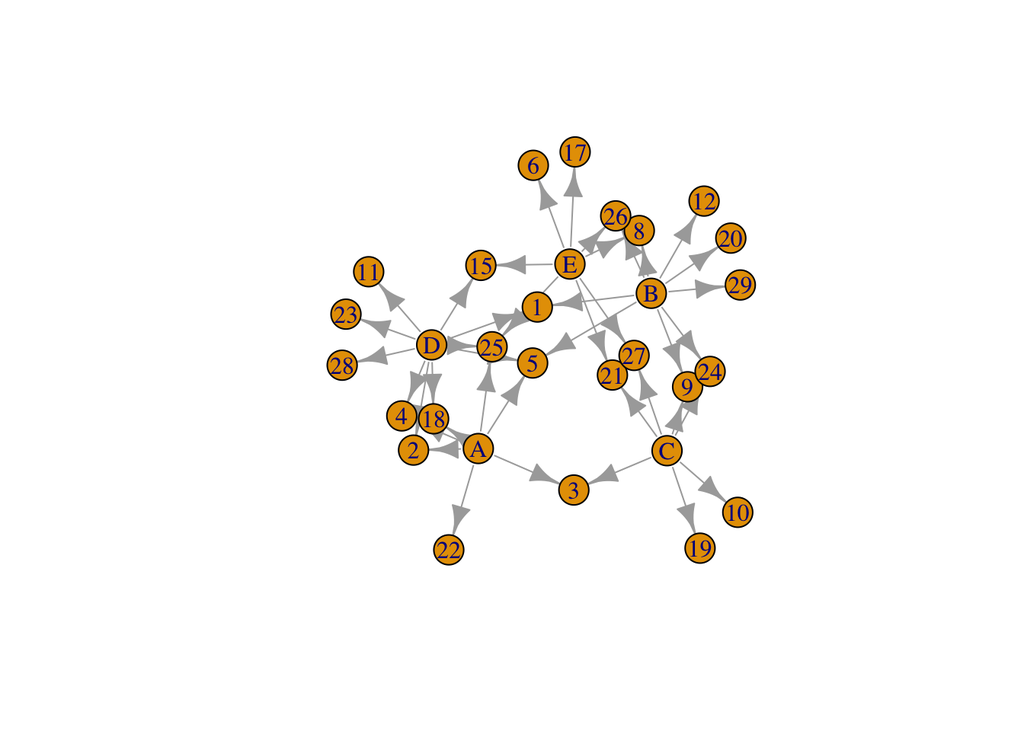

```r
#Load the igraph package
library(igraph)

#First we will make an object that contains the graph information using our two dataframes EDGE and VERTEX. Notice that we have made "directed = TRUE" - our graph is directed since discipline is being given from a teacher to a student.

g <- graph.data.frame(EDGE, directed=TRUE, vertices=VERTEX)

#Now we can plot our graph using the force directed graphing technique - our old friend Fruchertman-Reingold!

plot(g, layout=layout.fruchterman.reingold)
```

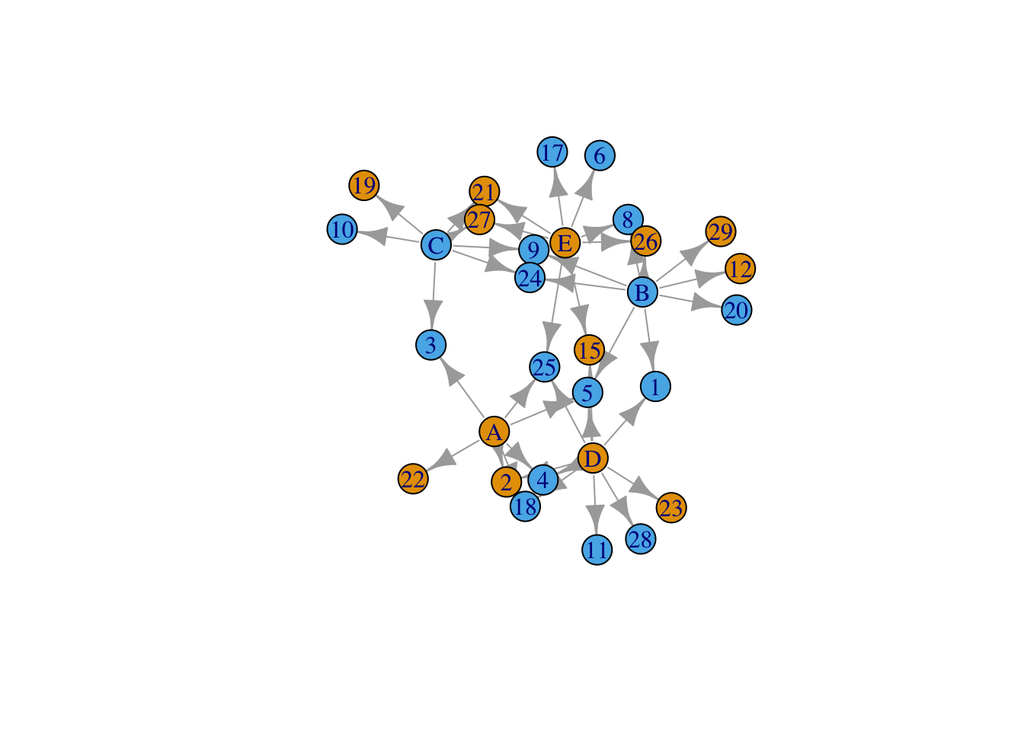

```r
#There are many ways to change the attributes of the graph to represent different characteristics of the newtork. For example, we can color the nodes according to gender.

plot(g, layout=layout.fruchterman.reingold, vertex.color=VERTEX$gender)
```

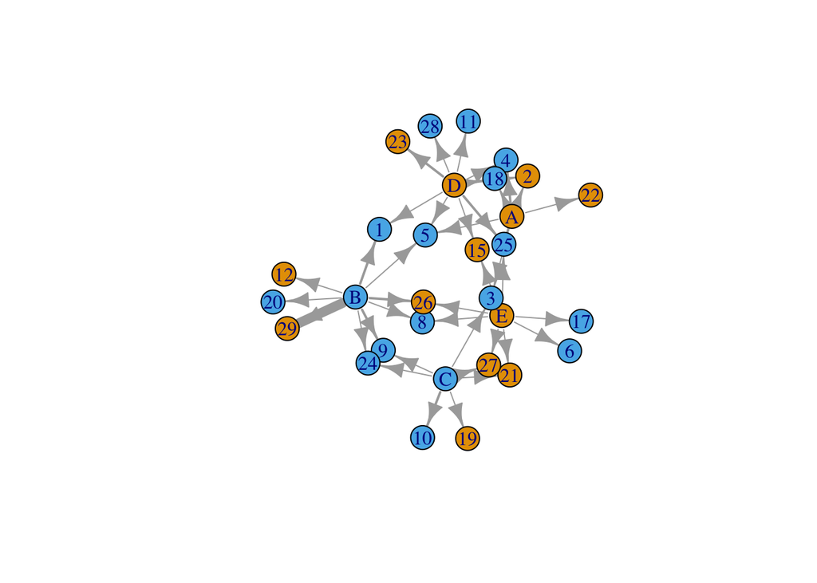

```r
#We can change the thickness of the edge according to the number of times a particular teacher has sent a particular student to the principal.

plot(g, layout=layout.fruchterman.reingold, vertex.color=VERTEX$gender, edge.width=EDGE$count)
```

## Part II

In Part II your task is to [look up](http://igraph.org/r/) in the igraph documentation and create a graph that sizes the student vertices in terms of the number of disciplinary actions they have recieved, and the teachers in terms of the number of disciplinary actions they have given out.

```r
# num of disciplinary actions: students
disc_tch <- EDGE %>%
  group_by(from) %>%
  summarize(sum_disc = sum(count)) %>%
  arrange(desc(sum_disc))
names(disc_tch) <- c("id", "num_disc")
disc_tch
```

```
## # A tibble: 5 x 2
##   id    num_disc
##   <fct>    <int>
## 1 B           19
## 2 D           12
## 3 A            9
## 4 C            8
## 5 E            8
```

```r
# num of disciplinary actions: teachers
disc_stu <- EDGE %>%
  group_by(to) %>%
  summarize(sum_disc = sum(count)) %>%
  arrange(desc(sum_disc))
names(disc_stu) <- c("id", "num_disc")
disc_stu
```

```
## # A tibble: 25 x 2
##    id    num_disc
##    <chr>    <int>
##  1 29           8
##  2 25           5
##  3 1            3
##  4 26           3
##  5 4            3
##  6 5            3
##  7 9            3
##  8 10           2
##  9 15           2
## 10 18           2
## # … with 15 more rows
```

```r
# merge the num of disciplinary actions of students & teachers
disc_all <- rbind(disc_tch, disc_stu)
disc_all
```

```
## # A tibble: 30 x 2
##    id    num_disc
##    <fct>    <int>
##  1 B           19
##  2 D           12
##  3 A            9
##  4 C            8
##  5 E            8
##  6 29           8
##  7 25           5
##  8 1            3
##  9 26           3
## 10 4            3
## # … with 20 more rows
```

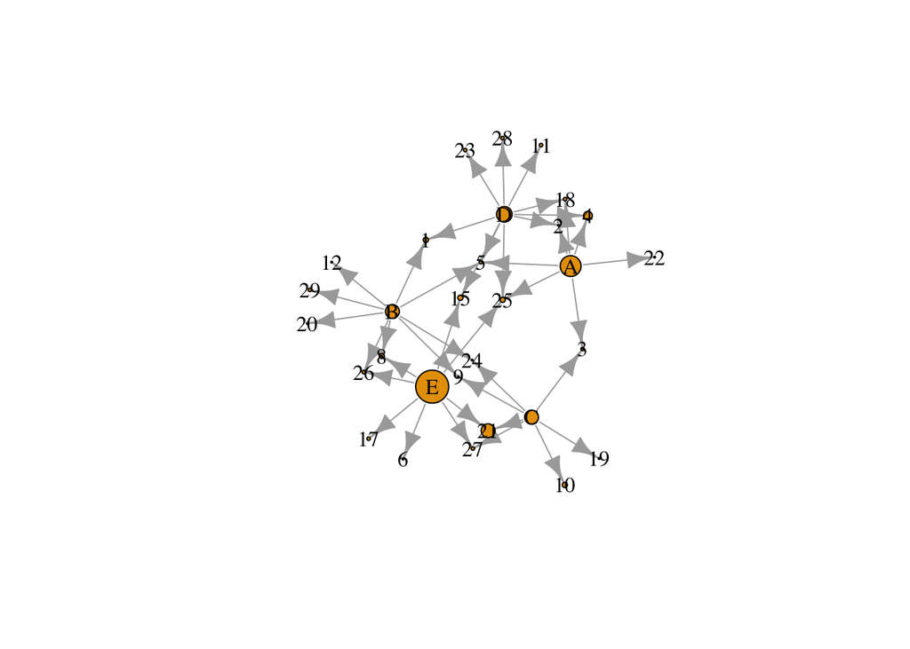

```r
# set the size of nodes to the number of disciplinary actions
node.size<-setNames(disc_all$num_disc, disc_all$id)

#
plot(g, layout = layout.fruchterman.reingold, edge.arrow.size = 1,
     vertex.label.color = "black", vertex.size = node.size)
```

## Part III

Now practice with data from our class. Please create a **person-network** with the data set hudk4050-classes.csv. To create this network you will need to create a person-class matrix using the tidyr functions and then create a person-person matrix using `t()`. You will then need to plot a matrix rather than a data frame using igraph.

Once you have done this, also [look up](http://igraph.org/r/) how to generate the following network metrics: betweenness centrality and dregree. **Who is the most central person in the network?**

Answer: Xudian Zhang is the most central person in the network in terms of betweenness centrality.  
Lintong Li is the most central person in the network in terms of degree.

### Data Cleaning

```r
library(tidyr)
library(dplyr)

# load data
hudk <- read.csv("hudk4050-classes.csv", header = TRUE, sep = ",")

# format: turn names from factors to characters
hudk$First.Name <- as.character(hudk$First.Name)
hudk$Last.Name <- as.character(hudk$Last.Name)

# format: write a function to capitalize the names
CapStr <- function(x) {
  s <- strsplit(x, " ")[[1]]
  paste(toupper(substring(s, 1,1)), tolower(substring(s, 2)), sep="", collapse=" ")
}
# apply the function
hudk$First.Name <- sapply(hudk$First.Name , CapStr)
hudk$Last.Name <- sapply(hudk$Last.Name , CapStr)

# combine first and last name
hudk$person <- paste(hudk$First.Name, hudk$Last.Name)

# drop the column of first and last name
hudk <- subset(hudk, select = c(person, Class.1, Class.2, Class.3, Class.4, Class.5, Class.6))

# format: revise the course names
levels(hudk$Class.3)[match("G 5067",levels(hudk$Class.3))] <- "QMSSG5067"
levels(hudk$Class.4)[match("G 5072",levels(hudk$Class.4))] <- "QMSSG5072"
levels(hudk$Class.1)[match("4050",levels(hudk$Class.1))] <- "HUDK4050"
levels(hudk$Class.2)[match("4125",levels(hudk$Class.2))] <- "HUDM4125"
levels(hudk$Class.3)[match("5026",levels(hudk$Class.3))] <- "HUDM5026"
levels(hudk$Class.4)[match("5126",levels(hudk$Class.4))] <- "HUDM5126"
levels(hudk$Class.3)[match("QMSS-G5072",levels(hudk$Class.3))] <- "QMSSG5072"
levels(hudk$Class.2)[match("IFSF4090002",levels(hudk$Class.2))] <- "ITSF4090"
levels(hudk$Class.3)[match("EDPS4002001",levels(hudk$Class.3))] <- "EDPS4002"
levels(hudk$Class.4)[match("EDPS4021001",levels(hudk$Class.4))] <- "EDPS4021"

# convert factor into character
hudk[] <- lapply(hudk, as.character)

# remove the space
hudk[2:7] <- as.data.frame(lapply(hudk[2:7],function(x){gsub(" ","",x)}))
hudk
```

```
##               person  Class.1  Class.2   Class.3    Class.4   Class.5
## 1       Artemas Wang HUDK4050 HUDK4052  HUDM5026
## 2          Yawei Zhu HUDK4050 HUDK4052  HUDK5053
## 3         Ningyao Xu HUDK4050 HUDM4125  HUDM5126   HUDM5026
## 4         Qiyang Lin HUDK4050 HUDM4122  HUDK4029   HUDK4080
## 5     Bernell Downer HUDK4050 HUDK4052  HUDM5126 QMSSGR5067
## 6         Ruiqi Wang HUDM4125 HUDM5026  HUDM5126   A&HA4063
## 7  Leonardo Restrepo HUDM5122 HUDM5026  HUDK4052   HUDK4050
## 8     Zhaozhuo Zheng HUDK4050 HUDK4052  HUDM4122   HUDM4120
## 9      Jiancong Shen HUDK4052 HUDK4050  HUDK4029   HUDM4050
## 10         Zifan Cao HUDK4050
## 11    Allison Teevan HUDK4050
## 12          Yiwen Ma HUDK4050 HUDM5026  HUDM5126   HUDM4125
## 13        Beibei Cao HUDK4050 EDPE6151  EDPE4155   EDPA4047
## 14         Yixiao Li HUDK4050 ITSF4090  EDPS4002   EDPS4021
## 15        Xinyi Zhou HUDK4050 HUDM4122  HUDK4052   MSTU4039
## 16      Jingru Zhang HUDK4050 HUDM4125  HUDM5126   ORLD4051
## 17        Ziyuan Guo HUDK4050 HUDM5026  HUDM4125   HUDM5126
## 18       Timothy Lee HUDK4050 HUDK4052 QMSSG5067  QMSSG5072
## 19           Xi Yang HUDK4050 HUDM4125  HUDM5026   HUDM5126
## 20        Chenyu Yan CCPX4023  HUD4120  HUDK4050   HUDK4052  HUDM4122
## 21          Yiyi Xie HUDK4052 HUDK4050     B8306   HUDM4122
## 22            Di Mao HUDM5026 HUDM5126  HUDM4125   HUDK4050 QMSSG5015
## 23          Han Wang HUDK4050 HUDK5011  MSTU5027
## 24      Xiaowen Chen HUDK4029 HUDK4050  HUDK4052   HUDM5123
## 25         Anqi Duan HUDK4050 HUDK4052  MSTU4052   HUDM5122
## 26           Ling Ai HUDK4050 HUDK5053  MSTU5002   MSTU4023
## 27          Yiwei Qi HUDK4050 HUDK5023   HUD4120
## 28        Jiahao Guo HUDK4050 HUDM4125  HUDM5126   HUDM5026
## 29     Lingling Miao HUDM4125 HUDM5026  HUDM5126   HUDK4050
## 30       Shijie Shao HUDK4050 HUDM4125  HUDM5026   HUDM5126
## 31       Yujun Zhang HUDK4050 HUDK4052  HUDK4080   HUDM5026  MSTU4052
## 32    Chaoxiong Chen HUDK4050 HUDK4052  HUDK4029   CCPJ5056
## 33        Lintong Li HUDM5026 HUDK4052  HUDK4050   HUDK4029
## 34         Zimo Chen HUDK4050 HUDM4125  HUDM5026   HUDM5126
## 35            Han Ge HUDK4050 HUDK4052  HUDK4029   MSTU4031  HUDM5123
## 36   Alysandra Zhang HUDM4122 CCPX4023  HUDK4050
## 37        Yixuan Zhu HUDK4050 HUDK4052  HUDK4029   MSTU4039
## 38      Xudian Zhang HUDK4050 HUDM4125  HUDM5026   HUDM5126  QMSS5015
## 39           Yaqi Lu HUDK4050 EDPE4056  ORLD4085   EDPA6002
```

[output cut: 53 more lines]

```
## 39
## 40
## 41
## 42
## 43
## 44
## 45
## 46
## 47
## 48
## 49 QMSS5021
## 50
## 51
## 52
## 53
```

### Person-class matrix

```r
# gather into long spreadsheet
hudk_long <- gather(hudk, "class", "course", 2:7)
hudk_long <- hudk_long[,-2]

# delete the rows with no course
hudk_long <- hudk_long[!(hudk_long$course==""), ]
hudk_long$count <- 1

# spread the class into column names
hudk_wide <- spread(hudk_long, course, count)

# set NA value to 0 (Not taking the course)
hudk_wide[is.na(hudk_wide)] <- 0
# set value to 1 (Taking the course)
hudk_wide[hudk_wide=="1"] <- 1

# change row name into index
row.names(hudk_wide) <- hudk_wide$person
hudk_wide <- hudk_wide[,-1]
hudk_wide
```

```
##                   A&HA4063 B8306 BBSN4904 BBSN5007 BBSN5019 CCPJ5056
## Allison Teevan           0     0        0        0        0        0
## Alysandra Zhang          0     0        0        0        0        0
## Anqi Duan                0     0        0        0        0        0
## Artemas Wang             0     0        0        0        0        0
## Beibei Cao               0     0        0        0        0        0
## Bernell Downer           0     0        0        0        0        0
## Chaoxiong Chen           0     0        0        0        0        1
## Chengxuan Hu             0     0        0        0        0        0
## Chenyu Yan               0     0        0        0        0        0
## Christine Odenath        0     0        0        1        0        0
## David Pearce             0     0        1        0        1        0
## Di Mao                   0     0        0        0        0        0
## Eudora Xinyi Niu         0     0        0        0        0        0
## Han Ge                   0     0        0        0        0        0
## Han Wang                 0     0        0        0        0        0
## Indira Batayeva          0     0        0        0        0        0
## Jiahao Guo               0     0        0        0        0        0
## Jiancong Shen            0     0        0        0        0        0
## Jie Chen                 0     0        0        0        0        0
## Jingru Zhang             0     0        0        0        0        0
## Joellyn Heng             0     0        0        0        0        0
## Leonardo Restrepo        0     0        0        0        0        0
## Ling Ai                  0     0        0        0        0        0
## Lingling Miao            0     0        0        0        0        0
## Lintong Li               0     0        0        0        0        0
## Luyi Dai                 0     0        0        0        0        0
## Maho Hayashi             0     0        0        0        0        0
## Minruo Wang              0     0        0        0        0        0
## Ningyao Xu               0     0        0        0        0        0
## Qiyang Lin               0     0        0        0        0        0
## Ruiqi Wang               1     0        0        0        0        0
## Shijie Shao              0     0        0        0        0        0
## Suwon Jung               0     0        0        0        0        0
## Timothy Lee              0     0        0        0        0        0
## Wanruo Zhang             1     0        0        0        0        0
## Xi Yang                  0     0        0        0        0        0
## Xiaowen Chen             0     0        0        0        0        0
## Xinyi Zhou               0     0        0        0        0        0
## Xudian Zhang             0     0        0        0        0        0
```

[output cut: 485 more lines]

```
## Xudian Zhang              0          0        0
## Yaqi Lu                   0          0        0
## Yawei Zhu                 0          0        0
## Yigao Liu                 0          0        0
## Yiwei Qi                  0          0        0
## Yiwen Ma                  0          0        0
## Yixiao Li                 0          0        0
## Yixuan Zhu                0          0        0
## Yiyi Xie                  0          0        0
## Yujun Zhang               0          0        0
## Zhaozhuo Zheng            0          0        0
## Zhongyuan Zhang           0          0        0
## Zifan Cao                 0          0        0
## Zimo Chen                 0          0        0
## Ziyuan Guo                0          0        0
```

```r
# convert into person-class matrix
#hudk_pplclass_mat <- matrix(hudk_wide)
#hudk_pplclass_mat
```

### Person-person matrix

```r
### person-person matrix ###
hudk_person_mat <- as.matrix(hudk_wide)
hudk_person_mat <- hudk_person_mat %*% t(hudk_person_mat)
```

### Build the Network

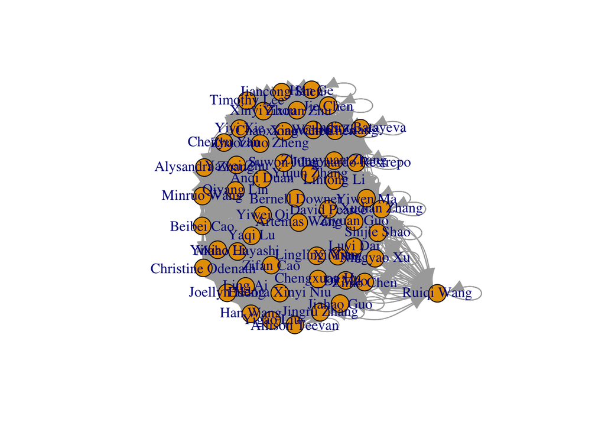

```r
# create graph from adjacency matrices
hudk_network <- graph.adjacency(hudk_person_mat)
plot(hudk_network, layout=layout.fruchterman.reingold)
```

```r
# between centrality
hudk_bet_centrality <- betweenness(hudk_network, directed = TRUE)
hudk_bet_centrality
```

```
##    Allison Teevan   Alysandra Zhang         Anqi Duan      Artemas Wang
##          0.000000          0.000000          0.000000          1.752846
##        Beibei Cao    Bernell Downer    Chaoxiong Chen      Chengxuan Hu
##          0.000000          1.752846          0.000000          3.722149
##        Chenyu Yan Christine Odenath      David Pearce            Di Mao
##          0.000000          0.000000          1.570716          3.722149
##  Eudora Xinyi Niu            Han Ge          Han Wang   Indira Batayeva
##          0.000000          0.000000          0.000000          0.000000
##        Jiahao Guo     Jiancong Shen          Jie Chen      Jingru Zhang
##          3.722149          0.000000          0.000000          2.481433
##      Joellyn Heng Leonardo Restrepo           Ling Ai     Lingling Miao
##          0.000000          1.788560          0.000000          3.722149
##        Lintong Li          Luyi Dai      Maho Hayashi       Minruo Wang
##          2.082846          3.722149          0.000000          0.000000
##        Ningyao Xu        Qiyang Lin        Ruiqi Wang       Shijie Shao
##          3.722149          0.000000          0.000000          3.722149
##        Suwon Jung       Timothy Lee      Wanruo Zhang           Xi Yang
##          0.000000          0.000000          2.082846          3.722149
##      Xiaowen Chen        Xinyi Zhou      Xudian Zhang           Yaqi Lu
##          0.000000          0.000000          3.844598          0.000000
##         Yawei Zhu         Yigao Liu          Yiwei Qi          Yiwen Ma
##          0.000000          0.000000          0.000000          3.722149
##         Yixiao Li        Yixuan Zhu          Yiyi Xie       Yujun Zhang
##          0.000000          0.000000          0.000000          1.911113
##    Zhaozhuo Zheng   Zhongyuan Zhang         Zifan Cao         Zimo Chen
##          0.000000          1.788560          0.000000          3.722149
##        Ziyuan Guo
##          3.722149
```

```r
# degree centrality
hudk_degree_centrality <- degree(hudk_network)
hudk_degree_centrality
```

```
##    Allison Teevan   Alysandra Zhang         Anqi Duan      Artemas Wang
##               104               122               158               184
##        Beibei Cao    Bernell Downer    Chaoxiong Chen      Chengxuan Hu
##               110               178               172               200
##        Chenyu Yan Christine Odenath      David Pearce            Di Mao
##               168               106               170               202
##  Eudora Xinyi Niu            Han Ge          Han Wang   Indira Batayeva
##               116               176               108               138
##        Jiahao Guo     Jiancong Shen          Jie Chen      Jingru Zhang
##               200               172               172               164
##      Joellyn Heng Leonardo Restrepo           Ling Ai     Lingling Miao
##               116               190               112               200
##        Lintong Li          Luyi Dai      Maho Hayashi       Minruo Wang
##               208               200               116               124
##        Ningyao Xu        Qiyang Lin        Ruiqi Wang       Shijie Shao
##               200               148               100               200
##        Suwon Jung       Timothy Lee      Wanruo Zhang           Xi Yang
##               170               152               176               200
##      Xiaowen Chen        Xinyi Zhou      Xudian Zhang           Yaqi Lu
##               174               164               204               110
##         Yawei Zhu         Yigao Liu          Yiwei Qi          Yiwen Ma
##               150               116               110               200
##         Yixiao Li        Yixuan Zhu          Yiyi Xie       Yujun Zhang
##               114               174               162               196
##    Zhaozhuo Zheng   Zhongyuan Zhang         Zifan Cao         Zimo Chen
##               164               190               104               200
##        Ziyuan Guo
##               200
```

### To Submit Your Assignment

Please submit your assignment by first “knitting” your RMarkdown document into an html file and then comit, push and pull request both the RMarkdown file and the html file.